# Instructions

```python
#evaluate the model
results = model2.evaluate(X_val, masks_val, verbose=1)
print("Val Dice coefficient:",results[1])
print("Val Loss:",results[0])
```

```
Val Dice coefficient: 0.4259541630744934
Val Loss: 1.4597803354263306
```

```
Original Image
```

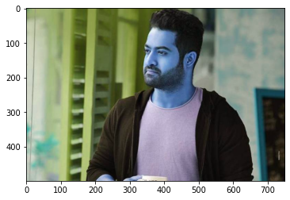

```
Predicted mask imposed on the image
```

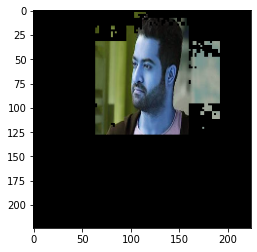

```
Mask
```

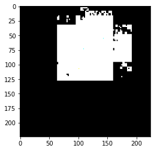

```
Original Image
```

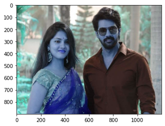

```
Predicted mask imposed on the image
```

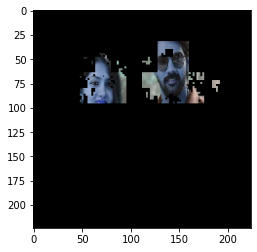

```
Mask
```

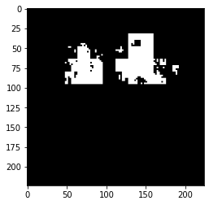

```
Original Image
```

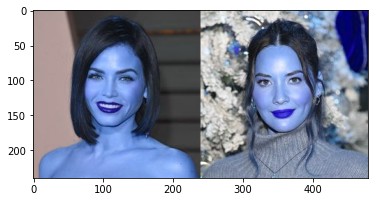

```
Predicted mask imposed on the image
```

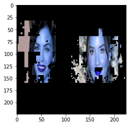

```
Mask
```

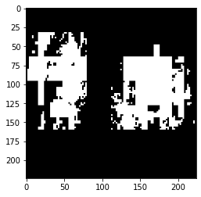

```
Original Image
```

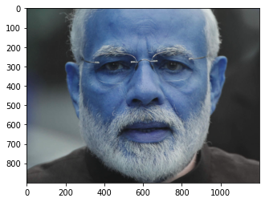

```
Predicted mask imposed on the image
```

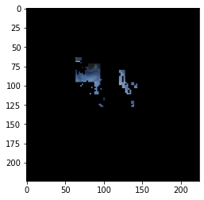

```
Mask
```

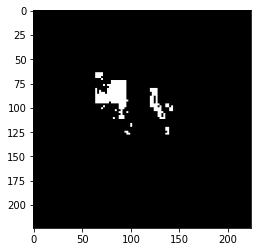

```python
import matplotlib.pyplot as plt
for filenam in filenames:
  print('*' * 50)
  filename = test_images_path + filenam
  unscaled = cv2.imread(filename)
  image = cv2.resize(unscaled, (IMAGE_WIDTH, IMAGE_HEIGHT))
  feat_scaled = preprocess_input(np.array(image, dtype=np.float32))

  pred_mask = cv2.resize(1.0*(model2.predict(x=np.array([feat_scaled]))[0] > 0.2), (IMAGE_WIDTH,IMAGE_HEIGHT))

  image2 = image
  image2[:,:,0] = pred_mask*image[:,:,0]
  image2[:,:,1] = pred_mask*image[:,:,1]
  image2[:,:,2] = pred_mask*image[:,:,2]

  out_image = image2
  print('Original Image')
  plt.imshow(unscaled)
  plt.show()
  print('Predicted mask imposed on the image')
  plt.imshow(out_image)
  plt.show()
  for i in range(224):
    for j in range(224):
      for k in range(3):
        if out_image[i][j][k]>0:
          out_image[i][j][k] = 255
  print('Mask')
  plt.imshow(out_image)
  plt.show()
```

# **Conclusions**

- I implemented the same mobilenet model with 2 implementations of Dice coefficient
- In the second implementation, I added a smoothing factor to the formulae of dice coefficient.
- I used pretrained Mobilenet architecture.
- I used Adam optimizer with a learning rate of 5e-6 because after hyper parameter tuning manually, I find this lr very efficient in reducing validation loss.
- A patience of 6 epochs was used for both the model implementations.

# Insights about the dataset

- One main thing which i found after testing with various images is our model is trained with data which has a lot of background(i.e.., person face covers less space in the whole image)
- This was drawn because modi sir picture's mask gave a bad predicted mask when compared to the actor NTR(first picture)
- Why the model couldn't recognize the whole mask in case of Modi sir image ? Maybe because the network did not see the data with that big bounding box.